# Homework #4

McKenna Goffinet; mgoffinet

3/4/2020

**1) Get a frequency breakdown of the number of chicks, their average weight and the standard deviation of the weights in each of the diets at the start of the study. Store the resulting data frame in a variable named weight0 and print.**

```r
weight0 <- ChickWeight %>% group_by(Diet) %>% summarize(num_chicks = n(), avg_weight= mean(weight), sd_weight= sd(weight))
weight0
```

```
## # A tibble: 4 x 4
##   Diet  num_chicks avg_weight sd_weight
##   <fct>      <int>      <dbl>     <dbl>
## 1 1            220       103.      56.7
## 2 2            120       123.      71.6
## 3 3            120       143.      86.5
## 4 4            118       135.      68.8
```

**2) Each chick should have twelve weight measurements. Use the dplyr package to identify how many measurements there are for each chick. Extract a subset of the data for all chicks with complete information, name the data set complete, and print the first 3 rows. (Hint: you might want to use mutate to introduce a helper variable consisting of the number of observations)**

```r
complete <- ChickWeight %>% group_by(Chick) %>% mutate(count = n()) %>% filter(count == 12)
complete[1:3,]
```

```
## # A tibble: 3 x 5
## # Groups:   Chick [1]
##   weight  Time Chick Diet  count
##    <dbl> <dbl> <ord> <fct> <int>
## 1     42     0 1     1        12
## 2     51     2 1     1        12
## 3     59     4 1     1        12
```

**3) In the complete data set introduce a new variable that measures the current weight difference compared to day 0. Name this variable weightgain and print the first 3 rows of the new data frame.**

```r
a <- complete %>% group_by(Chick) %>% filter(Time == 0)
complete$init_weight <- rep(a$weight, each=12)
complete <- complete %>% mutate(weightgain = weight - init_weight)
complete[1:3,]
```

```
## # A tibble: 3 x 7
## # Groups:   Chick [1]
##   weight  Time Chick Diet  count init_weight weightgain
##    <dbl> <dbl> <ord> <fct> <int>       <dbl>      <dbl>
## 1     42     0 1     1        12          42          0
## 2     51     2 1     1        12          42          9
## 3     59     4 1     1        12          42         17
```

**4) Use {ggplot2} to create side-by-side boxplots of weightgain by Diet for day 21. Change the order of the categories in the Diet variable such that the boxplots are ordered by median weightgain, and the lower limit of the y axis should be 0. Describe the relationship in 2-3 sentences.**

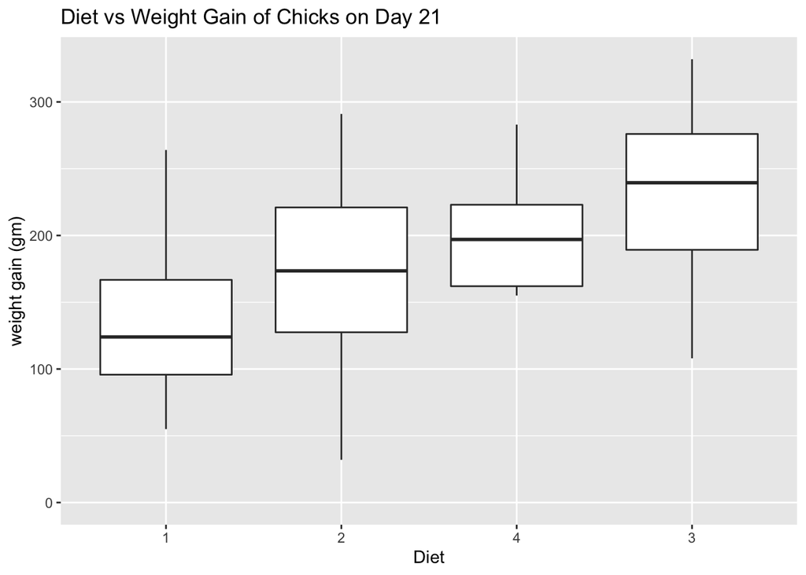

```r
complete$Diet <- factor(complete$Diet, levels(complete$Diet)[c(1,2,4,3)])
complete %>% filter(Time == 21) %>% ggplot(aes(x= Diet, y= weightgain)) + geom_boxplot() + expand_limits(y=0) + labs(y = 'weight gain (gm)', title = 'Diet vs Weight Gain of Chicks on Day 21')
```

Since all of the boxplots overlap, no one diet is categorically better than the others. However, Diet 1 has the lowest median weight gain, followed by Diet 2, Diet 4, and Diet 3, which has the highest median weight gain. As for consistency, Diet 4 has the narrowest range of the diets at roughly 125 grams, followed by Diet 1 (200g), Diet 3 (225g), and Diet 2, which has the widest range at about 250 grams.

**5) Answer each of the following questions using numerical and graphical summary. Also explain what you found: (a) Which chick gained the most weight and which gained the least weight? (b) What diets were they on?**

```r
final <- complete %>% filter(Time == 21)
max <- max(final$weightgain)
min <- min(final$weightgain)
final %>% filter(weightgain == max | weightgain == min)
```

```
## # A tibble: 2 x 7
## # Groups:   Chick [2]
##   weight  Time Chick Diet  count init_weight weightgain
##    <dbl> <dbl> <ord> <fct> <int>       <dbl>      <dbl>
## 1     74    21 24    2        12          42         32
## 2    373    21 35    3        12          41        332
```

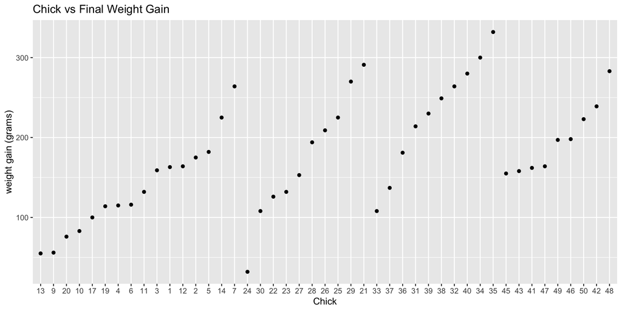

```r
final %>% ggplot(aes(x=Chick, y=weightgain)) + geom_point() + labs(y='weight gain (grams)', title='Chick vs Final Weight Gain')
```

Chick 24 gained the least weight (32 grams) and Chick 35 gained the most weight (332 grams). Chick 24 was on Diet 2 and Chick 35 was on Diet 3.

It fits with the previous questions results that the chick with the most weight gain was on diet 3 since diet 3 had the greatest median weight gain. While diet 2 didn’t have the lowest median weight gain, it had the greatest range of weight gains. In the above scatter plot the chicks are grouped based on diet, so the chicks on diet 1 are on the far left of the graph, followed by diets 2, 3, and 4. It shows that Chick 24 does contribute to the wide range of diet 2 as it’s a bit of an outlier among chicks on diet 2.

**6) For the chicks with the least and the most weight at time 0, plot their growth trajectories over time.**

```r
min <- min(complete$init_weight)
max <- max(complete$init_weight)
complete %>% filter(Time == 0 & (init_weight==min | init_weight == max))
```

```
## # A tibble: 10 x 7
## # Groups:   Chick [10]
##    weight  Time Chick Diet  count init_weight weightgain
##     <dbl> <dbl> <ord> <fct> <int>       <dbl>      <dbl>
##  1     43     0 3     1        12          43          0
##  2     43     0 11    1        12          43          0
##  3     43     0 19    1        12          43          0
##  4     43     0 23    2        12          43          0
##  5     39     0 27    2        12          39          0
##  6     39     0 28    2        12          39          0
##  7     39     0 29    2        12          39          0
##  8     39     0 33    3        12          39          0
##  9     39     0 36    3        12          39          0
## 10     39     0 48    4        12          39          0
```

From this we see that Chicks 3, 11, 19, and 23 weighed the most (43 grams) at time 0, and Chicks 27, 28, 29, 33, 36, and 48 weighed the least (39 grams) at time 0.

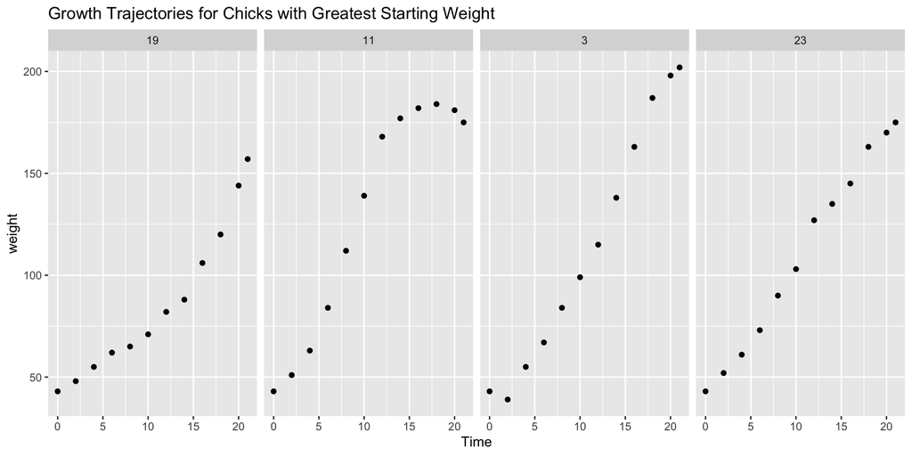

```r
complete %>%filter(Chick == 3 | Chick == 11 | Chick == 19 | Chick == 23)  %>% ggplot(aes(x=Time,y=weight)) + geom_point() + facet_grid(cols = vars(Chick)) + labs(title='Growth Trajectories for Chicks with Greatest Starting Weight')
```

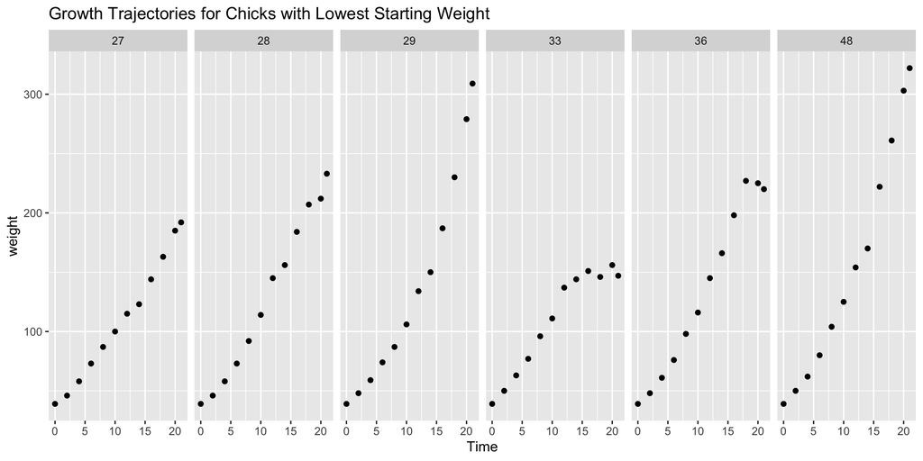

```r
complete %>%filter(Chick == 27 | Chick == 28 | Chick == 29 | Chick == 33 | Chick == 36 | Chick == 48)  %>% ggplot(aes(x=Time,y=weight)) + geom_point() + facet_grid(cols = vars(Chick)) + labs(title='Growth Trajectories for Chicks with Lowest Starting Weight')
```

The chicks at the lowest starting weight tended to gain more weight overall than the chicks that started at the greatest starting weight. The four chicks that started at the greatest weight all ended up roughly in the 150-200 gram range, whereas five of the six chicks that started at the lowest weight ended up weighing roughly 200 grams or more. The remaining chick of the six had some sort of growth stunt around 150 grams.

**7) Add to the previous plot the average growth trajectory for all chicks (calculated as the mean weight for each chick at each time). How do the trajectories compare?**

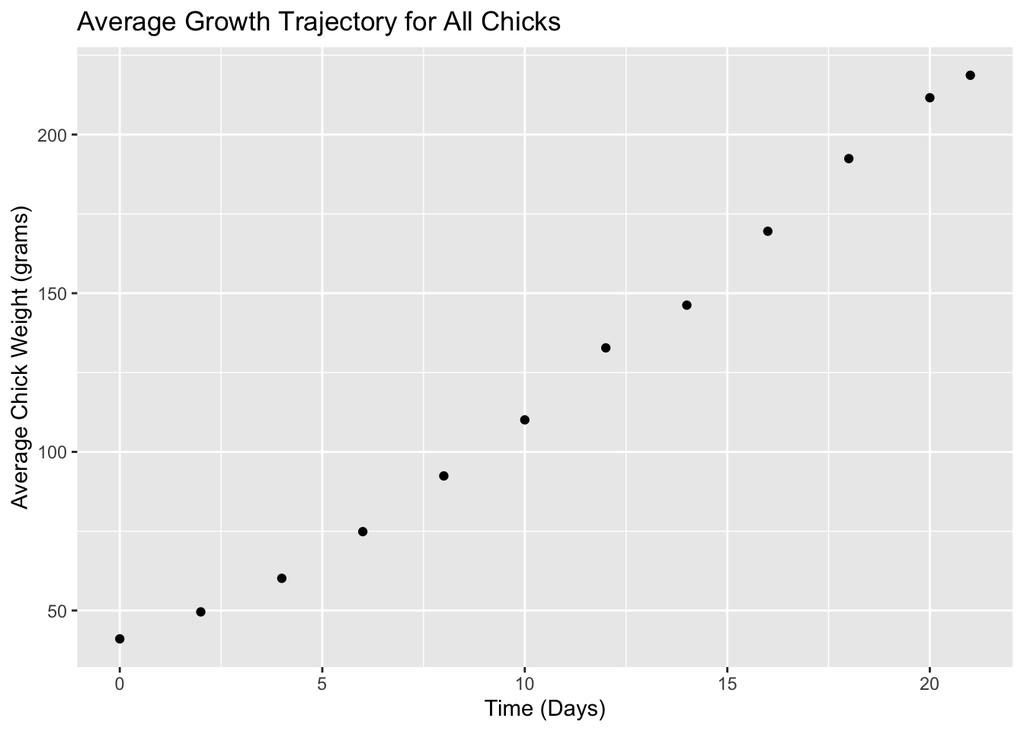

```r
wts <- complete %>% group_by(Time) %>% summarize(avg_wt = mean(weight))
wts %>% ggplot(aes(x=Time,y=avg_wt)) + geom_point() + labs(y='Average Chick Weight (grams)', x='Time (Days)',title='Average Growth Trajectory for All Chicks')
```

**8) What else do you find interesting in the dataset? Show your exploratory analysis.**

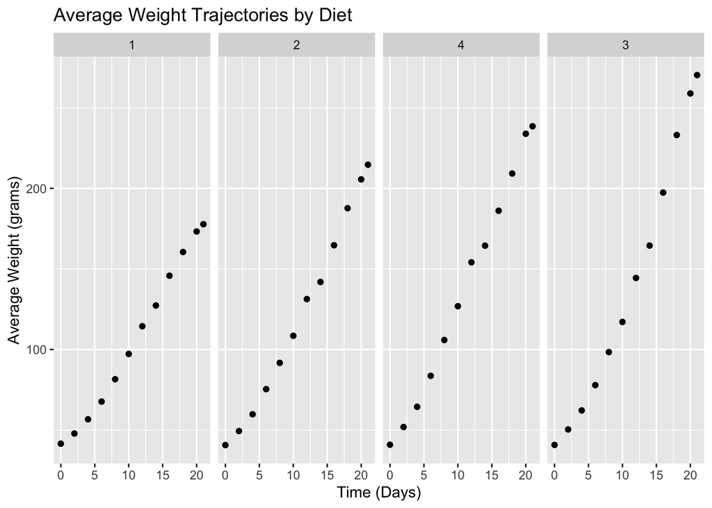

```r
complete %>% group_by(Diet, Time) %>% summarize(avg_wt = mean(weight)) %>% ggplot(aes(x=Time,y=avg_wt)) + geom_point() + facet_grid(cols = vars(Diet)) + labs(x='Time (Days)',y='Average Weight (grams)',title='Average Weight Trajectories by Diet')
```

All four groups of chicks had a similar starting average weight. Consistent with the earlier boxplot comparisons, Diet 3 has the greatest weight gain over the 21 day period, followed by Diets 4, 2, and 1. For all of the diets, the rate of weight gain begins at a similar rate. It isn’t until around day 8 that the diets begin to separate. Diet 4 shows a greater average weight gain than diet 3 around that time but does not maintain that rate like diet 3 does.